# Taller I

# BASE DE DATOS

En el presente taller se usará la base actualizada (data_banco(1)) donde se incluyen variables de las bases “Cajero” y “Sucursal” Nuevo_Sistema, Ubicación, Edad, Sexo, Nivel_Formación, Año.Ingreso y adicionalmente la variable Tiempo_Servicio_Seg en minutos como Tiempo_Servicio_Min.

```
 [1] "Sucursal"            "Cajero"              "ID_Transaccion"
 [4] "Transaccion"         "Tiempo_Servicio_seg" "Satisfaccion"
 [7] "Monto"               "Nuevo_Sistema"       "Ubicación"
[10] "Edad"                "Sexo"                "Nivel_Formacion"
[13] "Año.Ingreso"
```

```
'data.frame':   24299 obs. of  13 variables:
 $ Sucursal           : num  62 62 62 62 62 62 62 62 62 62 ...
 $ Cajero             : num  4820 4820 4820 4820 4820 4820 4820 4820 4820 4820 ...
 $ ID_Transaccion     : chr  "2" "2" "2" "2" ...
 $ Transaccion        : chr  "Cobro/Pago (Cta externa)" "Cobro/Pago (Cta externa)" "Cobro/Pago (Cta externa)" "Cobro/Pago (Cta externa)" ...
 $ Tiempo_Servicio_seg: num  311 156 248 99 123 172 140 247 183 91 ...
 $ Satisfaccion       : chr  "Muy Bueno" "Malo" "Regular" "Regular" ...
 $ Monto              : num  2889 1671 3172 1765 1836 ...
 $ Nuevo_Sistema      : chr  "No" "No" "No" "No" ...
 $ Ubicación          : chr  "Riocentro Sur" "Riocentro Sur" "Riocentro Sur" "Riocentro Sur" ...
 $ Edad               : num  42 42 42 42 42 42 42 42 42 42 ...
 $ Sexo               : chr  "F" "F" "F" "F" ...
 $ Nivel_Formacion    : chr  "Bachiller" "Bachiller" "Bachiller" "Bachiller" ...
 $ Año.Ingreso        : num  1995 1995 1995 1995 1995 ...
```

```
'data.frame':   24299 obs. of  14 variables:
 $ Sucursal           : chr  "62" "62" "62" "62" ...
 $ Cajero             : chr  "4820" "4820" "4820" "4820" ...
 $ ID_Transaccion     : chr  "2" "2" "2" "2" ...
 $ Transaccion        : chr  "Cobro/Pago (Cta externa)" "Cobro/Pago (Cta externa)" "Cobro/Pago (Cta externa)" "Cobro/Pago (Cta externa)" ...
 $ Tiempo_Servicio_seg: num  311 156 248 99 123 172 140 247 183 91 ...
 $ Satisfaccion       : Ord.factor w/ 5 levels "Muy Malo"<"Malo"<..: 5 2 3 3 5 4 3 4 5 5 ...
 $ Monto              : num  2889 1671 3172 1765 1836 ...
 $ Nuevo_Sistema      : chr  "No" "No" "No" "No" ...
 $ Ubicación          : chr  "Riocentro Sur" "Riocentro Sur" "Riocentro Sur" "Riocentro Sur" ...
 $ Edad               : num  42 42 42 42 42 42 42 42 42 42 ...
 $ Sexo               : chr  "F" "F" "F" "F" ...
 $ Nivel_Formacion    : chr  "Bachiller" "Bachiller" "Bachiller" "Bachiller" ...
 $ Año.Ingreso        : num  1995 1995 1995 1995 1995 ...
 $ Tiempo_Servicio_Min: num  5.18 2.6 4.13 1.65 2.05 ...
```

# Ejercicio 1

## Determine cuál es la fuente de variación más alta (entre todas las variables de la base de datos Data_Banco.xlsx) que afecta el tiempo de servicio.

-Necesitamos determinar cuan homogèneos o heterogéneos son los valores de nuestra variables, es decir, la dispersión , la variabilidad y la correlación de todas las variables con respecto a la variable tiempo de servicio.

Ahora realizamos un Análisis Exploratorio

#### Unidimensional

Se tiene una base de datos con 24299 registros correspondientes, con 14 variables, de las cuales se realiza un análisis de cada una con respecto al tiempo. Para iniciar el estudio en R obtenemos un resumen estadístico de las variables, como también su dispersión.

```
   Sucursal            Cajero          ID_Transaccion
 Length:24299       Length:24299       Length:24299
 Class :character   Class :character   Class :character
 Mode  :character   Mode  :character   Mode  :character


 Transaccion        Tiempo_Servicio_seg    Satisfaccion      Monto
 Length:24299       Min.   :  18.13     Muy Malo :3009   Min.   :  53.82
 Class :character   1st Qu.:  75.69     Malo     :4474   1st Qu.:1417.73
 Mode  :character   Median : 122.45     Regular  :4639   Median :2087.43
                    Mean   : 155.58     Bueno    :5915   Mean   :1996.16
                    3rd Qu.: 197.73     Muy Bueno:6262   3rd Qu.:2482.09
 Nuevo_Sistema       Ubicación              Edad           Sexo
 Length:24299       Length:24299       Min.   :22.00   Length:24299
 Class :character   Class :character   1st Qu.:26.00   Class :character
 Mode  :character   Mode  :character   Median :32.00   Mode  :character
                                       Mean   :33.45
                                       3rd Qu.:35.00
 Nivel_Formacion     Año.Ingreso   Tiempo_Servicio_Min
 Length:24299       Min.   :1984   Min.   : 0.3022
 Class :character   1st Qu.:2003   1st Qu.: 1.2615
 Mode  :character   Median :2012   Median : 2.0409
                    Mean   :2008   Mean   : 2.5930
                    3rd Qu.:2013   3rd Qu.: 3.2955
 [ reached getOption("max.print") -- omitted 1 row ]
```

```
[1] 2.359788
attr(,"method")
[1] "moment"
```

```
[1] 9.250124
attr(,"method")
[1] "excess"
```

En el caso de la variable tiempo de servicio la kurtosis nos indica que su distribución es màs apuntada que una normal..

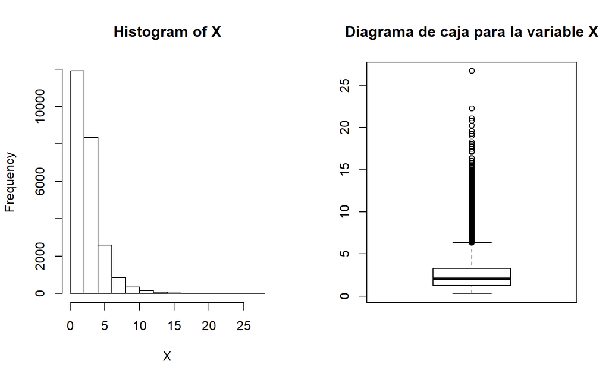

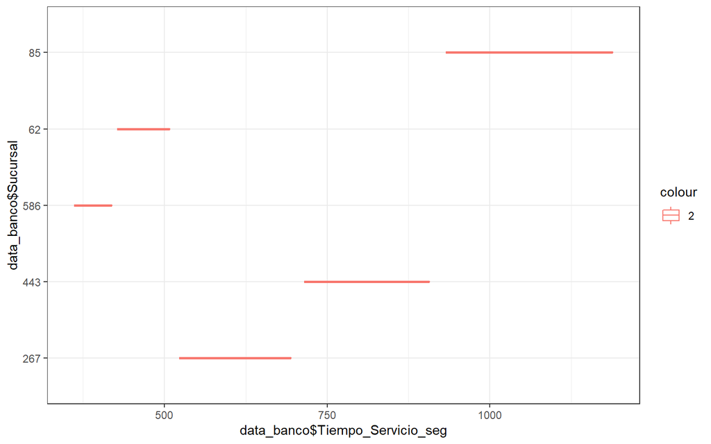

#### Bidimensional

```
[1] 0.5398951
```

```
[1] 0.02789692
```

```
[1] -0.01883639
```

El coeficiente de correlación para la variable tiemp de servicio con la variable Edad $0.02789692$ muestra que relación es positiva cercana a cero no mantienen relación entre variables.

El coeficiente de correlación para la variable tiempo de servicio y Año ingreso mantiene una relación negativa entre las variables.

Con lo que se puede concluir que la variable Monto es la variable que posee mayor influencia en la variable tiempo de servici

#### RESUMENES PARA DATOS AGRUPADOS

Calculamos la varianza entre las variables de la base de datos para analizar cuàl afecta el tiempo de servicio.

##### Análisis ANOVA

```
Analysis of Variance Table

Response: X
             Df Sum Sq Mean Sq F value    Pr(>F)
Y             4   8103 2025.65  552.28 < 2.2e-16 ***
Residuals 24294  89105    3.67
---
Signif. codes:  0 '***' 0.001 '**' 0.01 '*' 0.05 '.' 0.1 ' ' 1
```

```
Analysis of Variance Table

Response: X
             Df Sum Sq Mean Sq F value    Pr(>F)
Z            26   8441  324.66  88.774 < 2.2e-16 ***
Residuals 24272  88766    3.66
---
Signif. codes:  0 '***' 0.001 '**' 0.01 '*' 0.05 '.' 0.1 ' ' 1
```

```
Analysis of Variance Table

Response: X
             Df Sum Sq Mean Sq F value    Pr(>F)
C             1  28335 28334.6  9995.9 < 2.2e-16 ***
Residuals 24297  68873     2.8
---
Signif. codes:  0 '***' 0.001 '**' 0.01 '*' 0.05 '.' 0.1 ' ' 1
```

##### Análisis de varianza ANOVA

```
                       Df    Sum Sq Mean Sq F value Pr(>F)
data_banco$Sucursal     4  29169333 7292333   552.3 <2e-16 ***
Residuals           24294 320777021   13204
---
Signif. codes:  0 '***' 0.001 '**' 0.01 '*' 0.05 '.' 0.1 ' ' 1
```

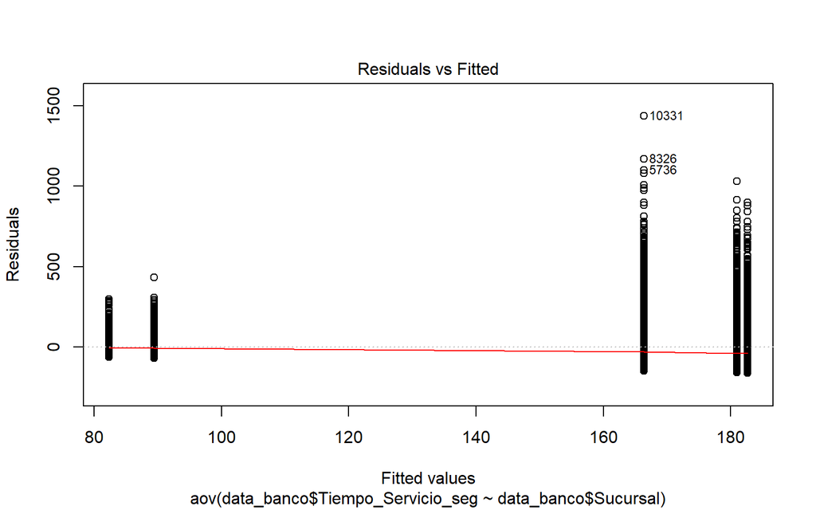

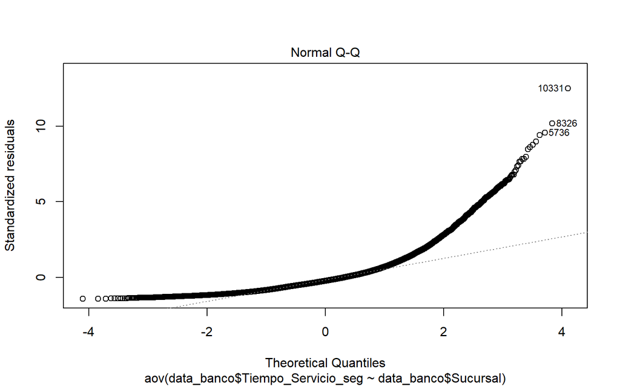

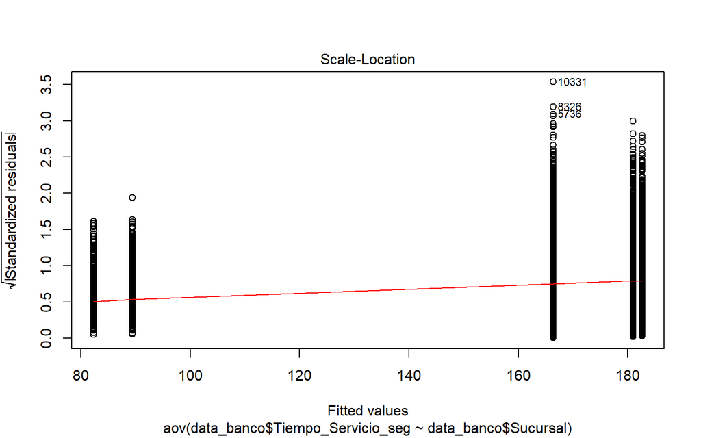

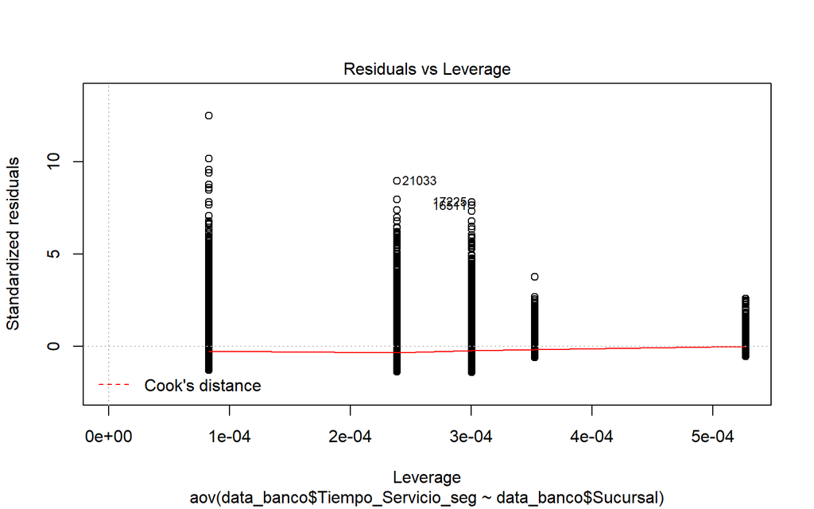

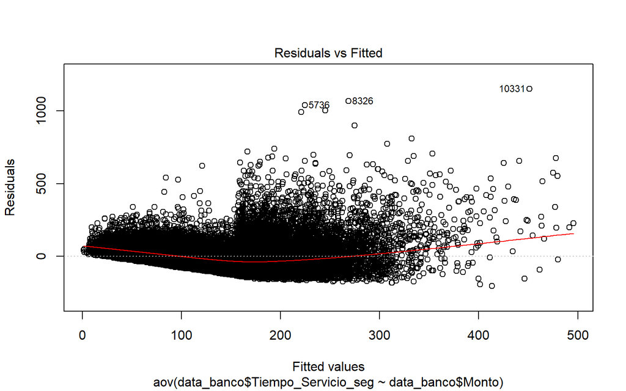

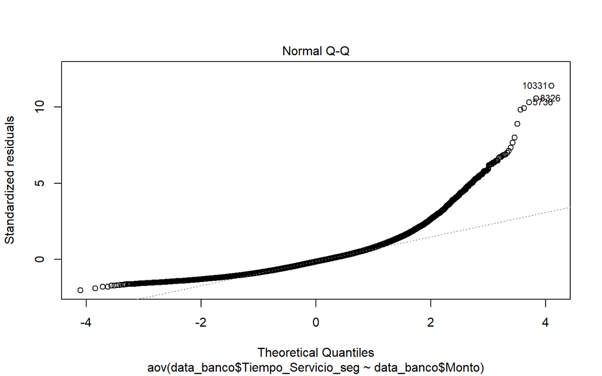

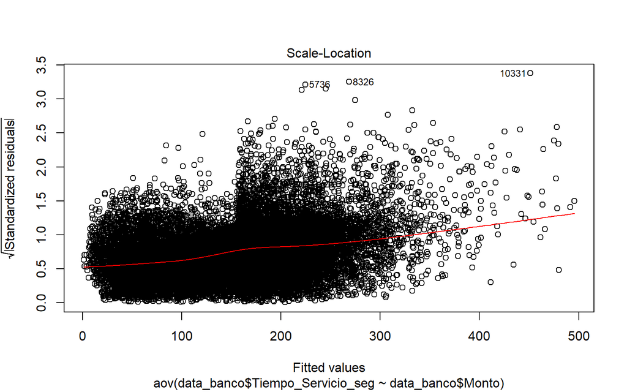

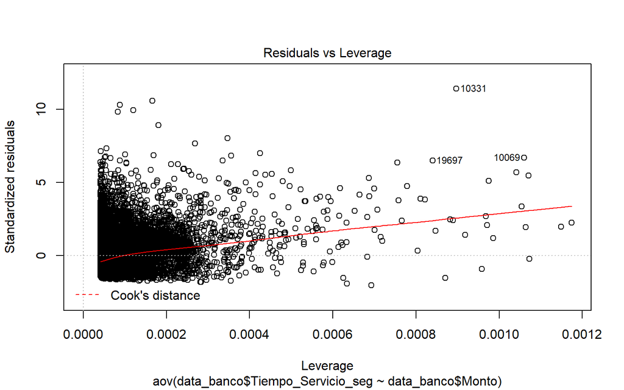

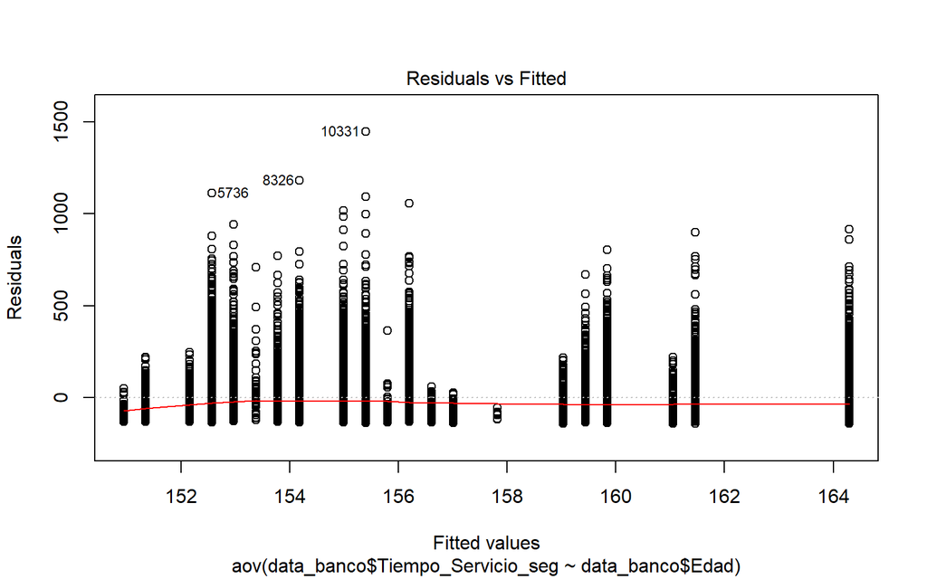

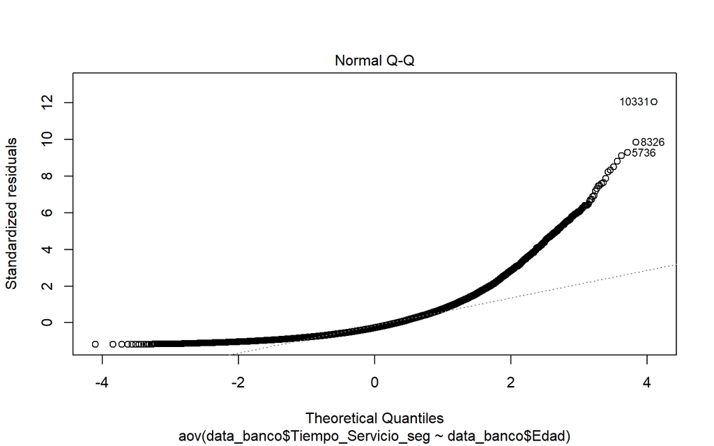

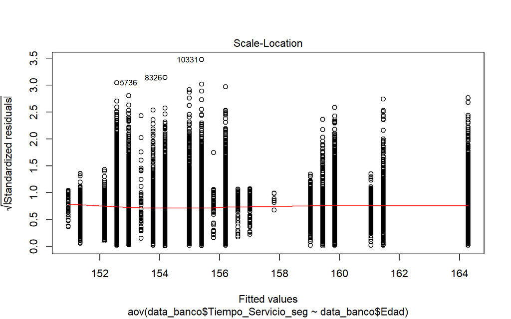

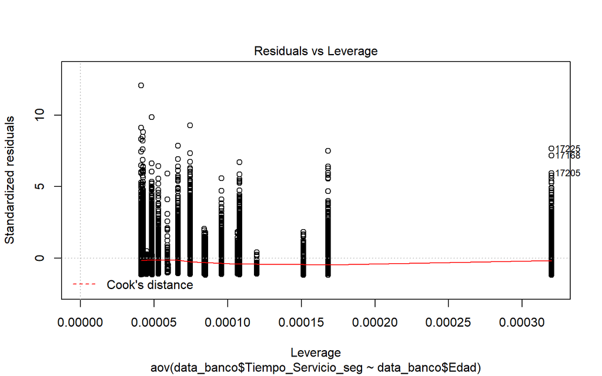

```
Call:
   aov(formula = data_banco$Tiempo_Servicio_seg ~ data_banco$Sucursal)

Terms:
                data_banco$Sucursal Residuals
Sum of Squares             29169333 320777021
Deg. of Freedom                   4     24294

Residual standard error: 114.9085
Estimated effects may be unbalanced
```

```
Call:
   aov(formula = data_banco$Tiempo_Servicio_seg ~ data_banco$Monto)

Terms:
                data_banco$Monto Residuals
Sum of Squares         102004709 247941645
Deg. of Freedom                1     24297

Residual standard error: 101.0179
Estimated effects may be unbalanced
```

```
Call:
   aov(formula = data_banco$Tiempo_Servicio_seg ~ data_banco$Edad)

Terms:
                data_banco$Edad Residuals
Sum of Squares           272342 349674012
Deg. of Freedom               1     24297

Residual standard error: 119.9652
Estimated effects may be unbalanced
```

# Ejercicio 2

### Análisis por Sexo del cajero

```
# A tibble: 4 x 3
  Sexo  Variable   `<NA>`
  <chr> <chr>       <dbl>
1 F     Cantidad 17746
2 F     Media        2.65
3 M     Cantidad  6553
4 M     Media        2.43
```

De los resultados obtenidos la diferencia entre el tiempo por sexo del cajero es de 0.22 min siendo el Sexo Masculino más eficiente en tiempo por transacción. Pero debemos recalcar que existen más mujeres realizando transacciones que hombres por loq ue el tiempo de mujeres un muy bueno en relación al de hombres

### Análisis por Ubicación

```
# A tibble: 10 x 3
   Ubicación     Variable   `<NA>`
   <chr>         <chr>       <dbl>
 1 Alborada      Cantidad  3329
 2 Alborada      Media        3.04
 3 Centro        Cantidad 12044
 4 Centro        Media        2.77
 5 Mall del Sol  Cantidad  4190
 6 Mall del Sol  Media        3.02
 7 Riocentro Sur Cantidad  2838
 8 Riocentro Sur Media        1.49
 9 Via Daule     Cantidad  1898
10 Via Daule     Media        1.37
```

Por otra parte la sucursal Vía Daule resulta ser la más eficiente en tiempo de servicio, pero debemos ver que las transacciones realizadas en esta sucursal son muy pocas a comparación del resto de Sucursales. Así la sucursal Centro que tiene 12044 transacciones varia en 1.4 min respecto a la sucursal Vía Daule

### Análisis por Nuevo_Sistema

```
# A tibble: 4 x 3
  Nuevo_Sistema Variable   `<NA>`
  <chr>         <chr>       <dbl>
1 No            Cantidad  4736
2 No            Media        1.44
3 Si            Cantidad 19563
4 Si            Media        2.87
```

Es evidente que el nuevo sistema predomina en la mayoría de sucursales del Banco, por lo que el tiempo de servicio varia en 1.43 min en relación al del nuevo servicio.

# Ejercicio 3

## Realice un perfilamiento por sucursal. Con el objetivo de determinar por que una sucursal es mejor que otra según la evaluación del cliente.

```
# A tibble: 5 x 2
  Ubicación     Indicador
  <chr>             <dbl>
1 Alborada           2.99
2 Via Daule          3.12
3 Riocentro Sur      3.15
4 Mall del Sol       3.44
5 Centro             3.46
```

Gracias al Indicador de Satisfacción la Sucursal Centro Obtuvo una mejor calificación, pero debemos tomar en cuenta que por el literal anterior que en esta sucursal se realizan 12044 transacciones de 24299 por lo que es claro que tendrá más calificaciones de satisfacción que el resto de sucursales.

# Ejercicio 4

```r
  Atipico <- function(x){
  N <- length(x)
  UM <- sum(is.na(x))
  n <- N - UM
  x <- x[!(is.na(x) > 0)]
  LQ1 <- (n + 1)/4
  LQ3 <- (3 * (n + 1))/4
  Sort <- sort(x)
  V1 <- floor(LQ1)
  V2 <- floor(LQ3)
  V3 <- V1 + 1
  V4 <- V2 + 1
  Q1 <- round(Sort[V1] + (LQ1 - V1) * (Sort[V3] - Sort[V1]),
              3)
  Q3 <- round(Sort[V2] + (LQ3 - V2) * (Sort[V4] - Sort[V2]),
              3)
  IQR <- round(Q3 - Q1, 3)
  l.out <- x[x < (Q1 - 1.5 * IQR)]
  r.out <- x[x > (Q3 + 1.5 * IQR)]
  outliers <- c(l.out, r.out)
  pos <- which(x %in% outliers)
  return(pos)
}
```

# Ejercicio 5

## Realizar una evaluación de los cajeros que considere el sexo, el tiempo de servicio, tiempo de experiencia, número de transacciones, monto procesado y evaluación del cliente.

| Cajero | Sexo | Experiencia | Año.Ingreso | Media_TiempoServicioMin | Total_Monto | Numero_Transacciones | Satisfacción |
| --- | --- | --- | --- | --- | --- | --- | --- |
| 56 | M | 21 | 1998 | 1.394752 | 1452282.31 | 832 | 2.861779 |
| 63 | F | 11 | 2008 | 1.363580 | 137800.01 | 81 | 2.691358 |
| 70 | F | 4 | 2015 | 2.840671 | 1351483.00 | 656 | 3.538110 |
| 87 | F | 11 | 2008 | 1.116667 | 13355.99 | 7 | 4.000000 |
| 299 | F | 2 | 2017 | 1.371636 | 1020013.62 | 597 | 3.532663 |
| 321 | M | 3 | 2016 | 1.955556 | 5252.77 | 3 | 3.000000 |
| 357 | F | 8 | 2011 | 2.884891 | 3808131.96 | 1832 | 3.329694 |
| 472 | F | 6 | 2013 | 2.976868 | 5762505.22 | 2764 | 3.357453 |
| 2230 | M | 9 | 2010 | 3.536050 | 122236.53 | 53 | 3.188679 |
| 2503 | F | 20 | 1999 | 3.001065 | 3295642.03 | 1578 | 3.043726 |
| 2556 | M | 22 | 1997 | 3.091813 | 1376058.35 | 667 | 3.113943 |
| 2623 | F | 2 | 2017 | 1.273718 | 309397.43 | 182 | 2.994505 |
| 2958 | F | 7 | 2012 | 2.926876 | 2713432.04 | 1327 | 3.566692 |
| 3023 | M | 3 | 2016 | 1.382680 | 84924.13 | 51 | 3.647059 |
| 3327 | F | 3 | 2016 | 1.366216 | 60140.63 | 37 | 2.945946 |
| 3678 | M | 7 | 2012 | 2.760527 | 4011676.49 | 1962 | 3.302752 |
| 3732 | M | 6 | 2013 | 2.954469 | 2773137.88 | 1339 | 3.215086 |
| 3983 | F | 6 | 2013 | 2.600984 | 8598798.42 | 4280 | 3.678738 |
| 4208 | F | 16 | 2003 | 3.136120 | 3101820.24 | 1471 | 3.528212 |
| 4353 | F | 8 | 2011 | 1.746429 | 23211.77 | 14 | 3.071429 |
| 4424 | F | 17 | 2002 | 1.316489 | 157794.26 | 94 | 3.223404 |
| 4796 | F | 35 | 1984 | 3.076423 | 2197877.14 | 1084 | 2.835793 |
| 4820 | F | 24 | 1995 | 1.485786 | 1872210.47 | 1067 | 3.141518 |
| 4837 | M | 18 | 2001 | 2.683799 | 1137599.52 | 550 | 3.101818 |
| 5174 | M | 9 | 2010 | 1.710638 | 87428.62 | 47 | 2.531915 |
| 5211 | F | 2 | 2017 | 1.522123 | 1191109.20 | 675 | 2.961482 |
| 5286 | M | 7 | 2012 | 1.463394 | 1839278.23 | 1049 | 3.298379 |

Lizeth Moreno, María Belén Rosero

2019-11-11